# Marketing Strategies for Carrefour Kenya

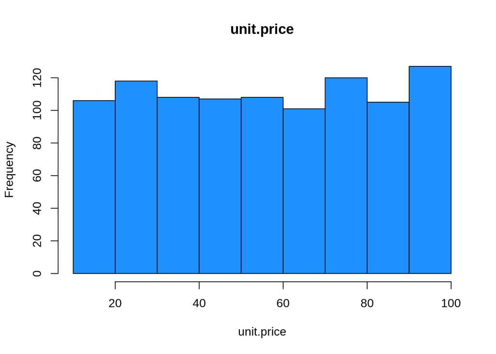

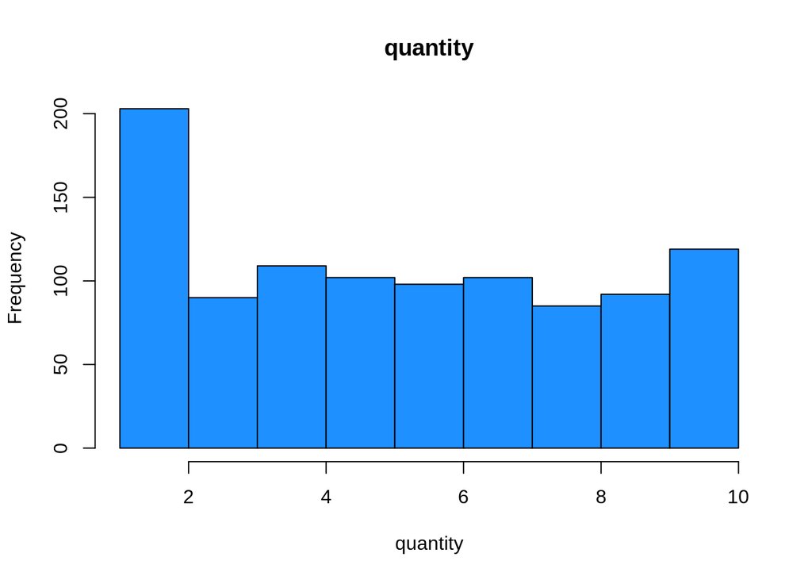

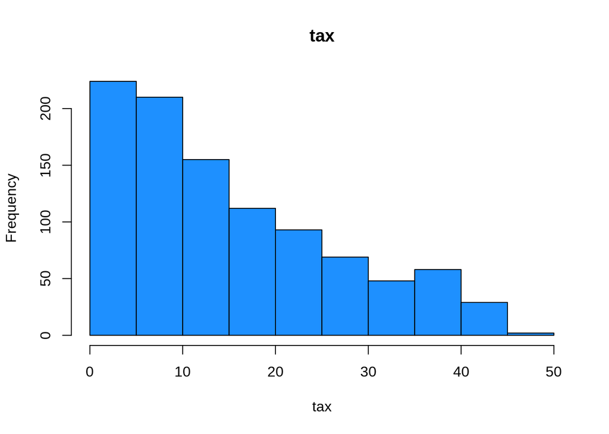

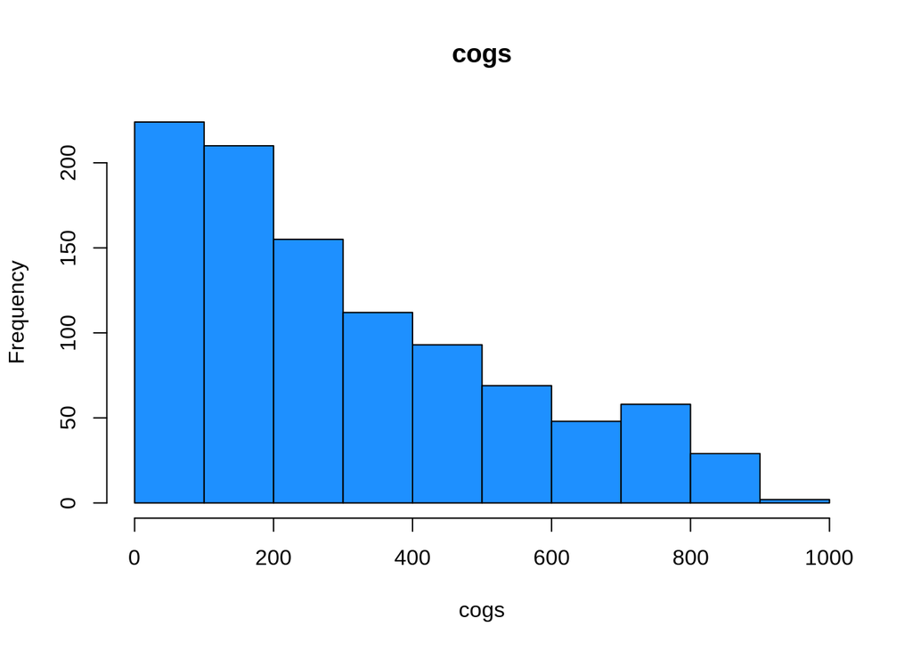

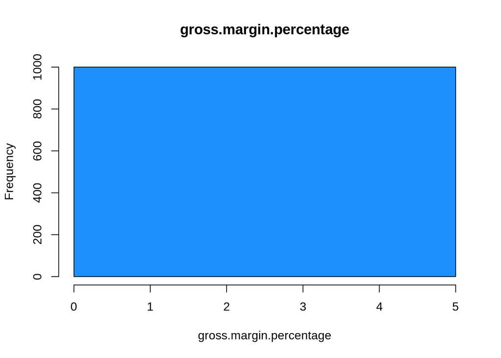

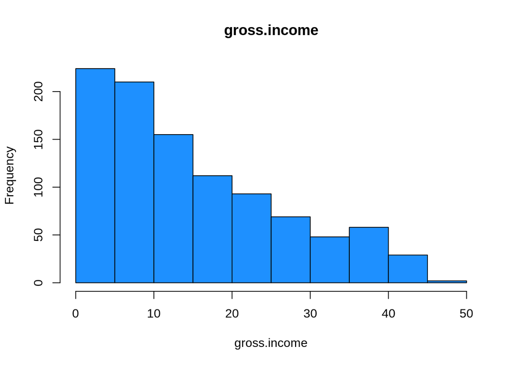

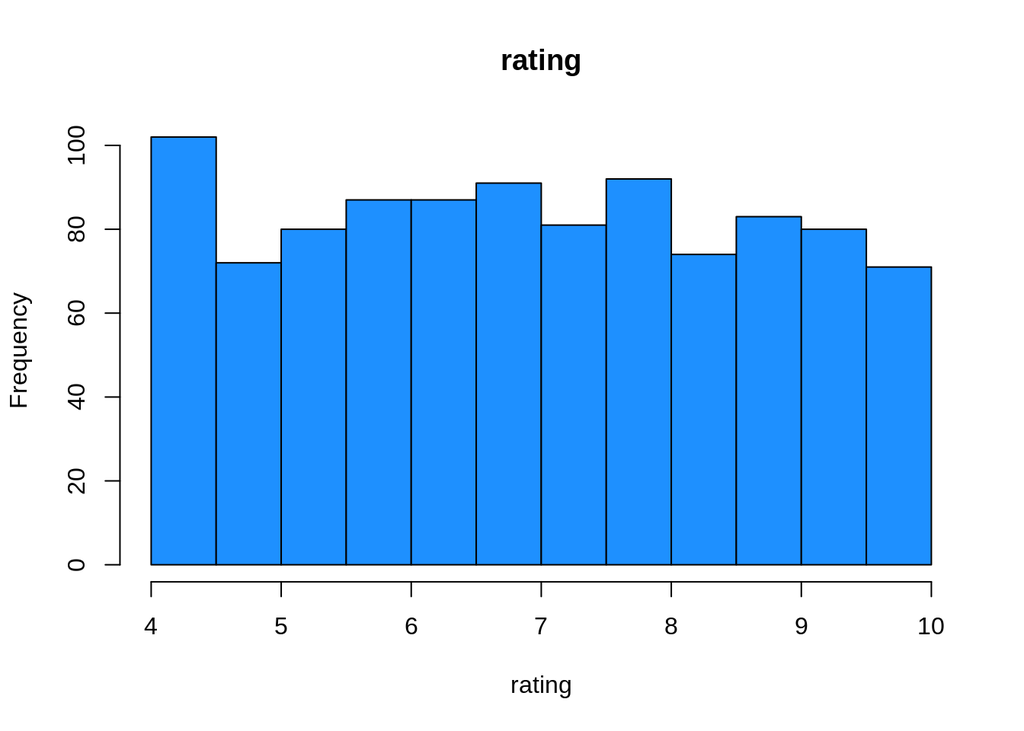

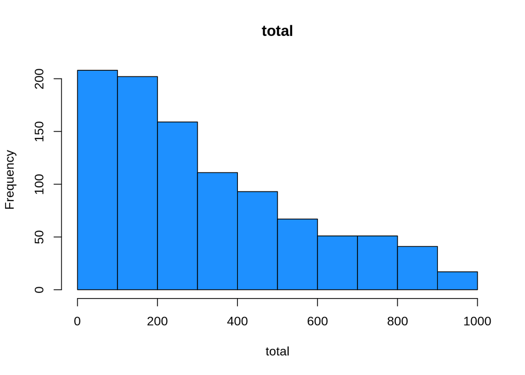

```r
histogram = function(x){
  for(i in colnames(x)){
    hist(sales_new[[i]], breaks = 10,main =i,xlab = i,col = "dodgerblue")
  }
}

histogram(num_col)
```

## Bivariate

### Correlation

```r
# Label Encode Categorical Variables
encode_ordinal <- function(x, order = unique(x)) {
  x <- as.numeric(factor(x, levels = order, exclude = NULL))
  x
}
table(sales_new$branch, encode_ordinal(sales_new$branch))
```

```
##
##       1   2   3
##   A 340   0   0
##   B   0   0 332
##   C   0 328   0
```

```r
table(sales_new$customer.type,encode_ordinal(sales_new$customer.type))
```

```
##
##            1   2
##   Member 501   0
##   Normal   0 499
```

```r
table(sales_new$gender, encode_ordinal(sales_new$gender))
```

```
##
##            1   2
##   Female 501   0
##   Male     0 499
```

```r
table(sales_new$product.line, encode_ordinal(sales_new$product.line))
```

```
##
##                            1   2   3   4   5   6
##   Electronic accessories   0 170   0   0   0   0
##   Fashion accessories      0   0   0   0   0 178
##   Food and beverages       0   0   0   0 174   0
##   Health and beauty      152   0   0   0   0   0
##   Home and lifestyle       0   0 160   0   0   0
##   Sports and travel        0   0   0 166   0   0
```

```r
table(sales_new$payment, encode_ordinal(sales_new$payment))
```

```
##
##                 1   2   3
##   Cash          0 344   0
##   Credit card   0   0 311
##   Ewallet     345   0   0
```

```r
sales_new$branch_enc <- encode_ordinal(sales_new$branch)
sales_new$customer.type_enc <- encode_ordinal(sales_new$customer.type)
sales_new$gender_enc <- encode_ordinal(sales_new$gender)
sales_new$product.line_enc <- encode_ordinal(sales_new$product.line)
sales_new$payment_enc <- encode_ordinal(sales_new$payment)

head(sales_new)
```

```
##   branch customer.type gender           product.line unit.price quantity
## 1      A        Member Female      Health and beauty      74.69        7
## 2      C        Normal Female Electronic accessories      15.28        5
## 3      A        Normal   Male     Home and lifestyle      46.33        7
## 4      A        Member   Male      Health and beauty      58.22        8
## 5      A        Normal   Male      Sports and travel      86.31        7
## 6      C        Normal   Male Electronic accessories      85.39        7
##       tax      date  time     payment   cogs gross.margin.percentage
## 1 26.1415  1/5/2019 13:08     Ewallet 522.83                4.761905
## 2  3.8200  3/8/2019 10:29        Cash  76.40                4.761905
## 3 16.2155  3/3/2019 13:23 Credit card 324.31                4.761905
## 4 23.2880 1/27/2019 20:33     Ewallet 465.76                4.761905
## 5 30.2085  2/8/2019 10:37     Ewallet 604.17                4.761905
## 6 29.8865 3/25/2019 18:30     Ewallet 597.73                4.761905
##   gross.income rating    total branch_enc customer.type_enc gender_enc
## 1      26.1415    9.1 548.9715          1                 1          1
## 2       3.8200    9.6  80.2200          2                 2          1
## 3      16.2155    7.4 340.5255          1                 2          2
## 4      23.2880    8.4 489.0480          1                 1          2
## 5      30.2085    5.3 634.3785          1                 2          2
## 6      29.8865    4.1 627.6165          2                 2          2
##   product.line_enc payment_enc
## 1                1           1
## 2                2           2
## 3                3           3
## 4                1           1
## 5                4           1
## 6                2           1
```

```r
# the correlation matrix
feat <- sales_new[, c(-1,-2,-3,-4,-8,-9,-10,-12)]
#head(feat)

correlation_matrix <- cor(feat)
library(corrplot)
corr_data <- as.data.frame(correlation_matrix)
corr_data
```

```
##                     unit.price     quantity          tax         cogs
## unit.price         1.000000000  0.010777564  0.633840195  0.633840195
## quantity           0.010777564  1.000000000  0.707051294  0.707051294
## tax                0.633840195  0.707051294  1.000000000  1.000000000
## cogs               0.633840195  0.707051294  1.000000000  1.000000000
## gross.income       0.633840195  0.707051294  1.000000000  1.000000000
## rating            -0.008777507 -0.015814905 -0.033923648 -0.033923648
## total              0.633840195  0.707051294  1.000000000  1.000000000
## branch_enc         0.013763477  0.002120920  0.012050301  0.012050301
## customer.type_enc -0.020237875 -0.016762706 -0.022321843 -0.022321843
## gender_enc         0.015444630 -0.074258307 -0.047850581 -0.047850581
## product.line_enc   0.038427649 -0.062514713 -0.022458599 -0.022458599
## payment_enc       -0.019637884  0.007333388  0.007536008  0.007536008
##                   gross.income       rating        total   branch_enc
## unit.price         0.633840195 -0.008777507  0.633840195  0.013763477
## quantity           0.707051294 -0.015814905  0.707051294  0.002120920
## tax                1.000000000 -0.033923648  1.000000000  0.012050301
## cogs               1.000000000 -0.033923648  1.000000000  0.012050301
## gross.income       1.000000000 -0.033923648  1.000000000  0.012050301
## rating            -0.033923648  1.000000000 -0.033923648 -0.049585348
## total              1.000000000 -0.033923648  1.000000000  0.012050301
## branch_enc         0.012050301 -0.049585348  0.012050301  1.000000000
## customer.type_enc -0.022321843  0.018888672 -0.022321843 -0.004899261
## gender_enc        -0.047850581  0.004800208 -0.047850581 -0.012218875
## product.line_enc  -0.022458599  0.023390962 -0.022458599  0.012575246
## payment_enc        0.007536008  0.013001094  0.007536008  0.026725563
##                   customer.type_enc   gender_enc product.line_enc  payment_enc
## unit.price             -0.020237875  0.015444630       0.03842765 -0.019637884
## quantity               -0.016762706 -0.074258307      -0.06251471  0.007333388
## tax                    -0.022321843 -0.047850581      -0.02245860  0.007536008
## cogs                   -0.022321843 -0.047850581      -0.02245860  0.007536008
## gross.income           -0.022321843 -0.047850581      -0.02245860  0.007536008
## rating                  0.018888672  0.004800208       0.02339096  0.013001094
## total                  -0.022321843 -0.047850581      -0.02245860  0.007536008
## branch_enc             -0.004899261 -0.012218875       0.01257525  0.026725563
## customer.type_enc       1.000000000  0.039996160      -0.02510945 -0.069286242
## gender_enc              0.039996160  1.000000000      -0.06612647 -0.049514182
## product.line_enc       -0.025109450 -0.066126475       1.00000000  0.010510982
## payment_enc            -0.069286242 -0.049514182       0.01051098  1.000000000
```

[figure not shown]

```r
corr <- corrplot(correlation_matrix, method = "shade",order = "hclust", col=colorRampPalette(c("yellow","green","navyblue"))(100), addgrid.col="gray", tl.col = "black", tl.cex = 0.7,tl.srt = 45)
```

### Graph Analysis

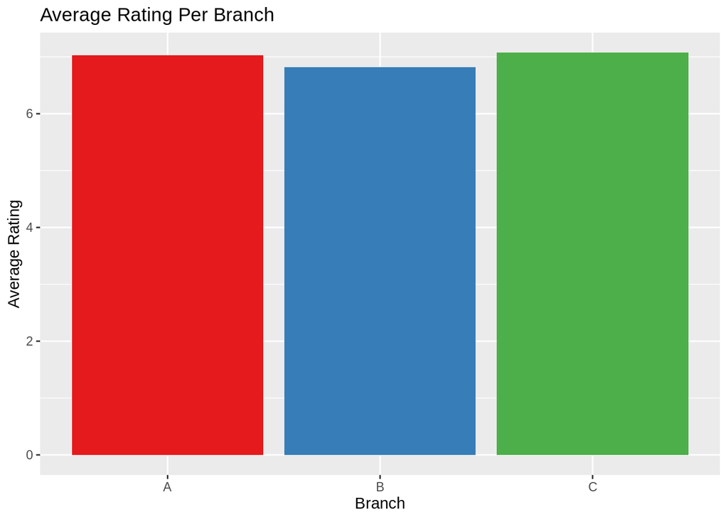

```r
# Which Branch received the highest Average rating

by_rate <- sales_new %>%
  group_by(branch) %>%
  summarise(rate = mean(rating))

rate <- ggplot(by_rate, aes(x=branch, y= rate, fill=branch))+geom_bar(stat = "identity")+ labs(title = "Average Rating Per Branch", x="Branch",y="Average Rating")
rate + scale_fill_brewer(palette="Set1")+theme(legend.position = "none")
```

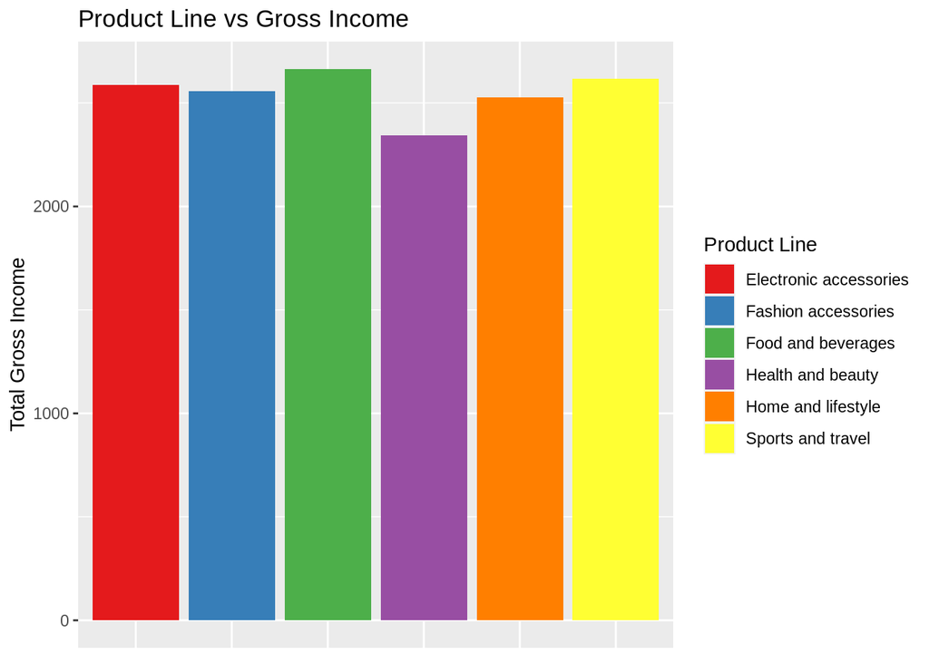

```r
# Product Line with Highest Gross Income
by_gross <- sales_new %>%
  group_by(product.line) %>%
  summarise(gross = sum(gross.income))


gross_inc <- ggplot(by_gross, aes(x=product.line, y= gross, fill=product.line))+geom_bar(stat = "identity")+ labs(title = "Product Line vs Gross Income", x="Product Line",y="Total Gross Income")
gross_inc + scale_fill_brewer(name="Product Line",palette="Set1")+theme(axis.title.x=element_blank(),
        axis.text.x=element_blank(),
        axis.ticks.x=element_blank())
```

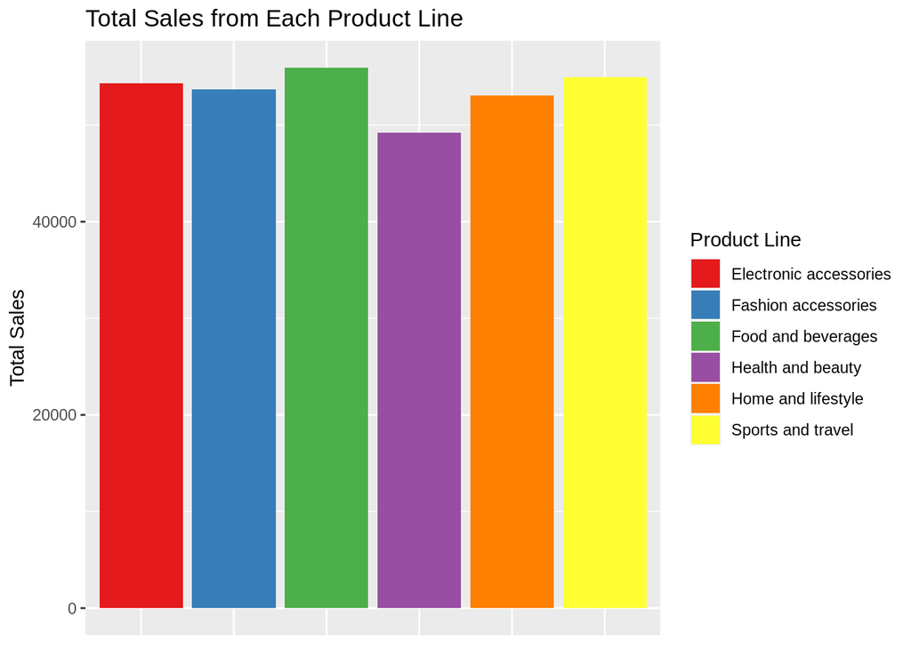

```r
# Total Sales for Each Product Line
by_sale <- sales_new %>%
  group_by(product.line) %>%
  summarise(total = sum(total))


total_sale <- ggplot(by_sale, aes(x=product.line, y= total, fill=product.line))+geom_bar(stat = "identity")+ labs(title = "Total Sales from Each Product Line", x="Product Line",y="Total Sales")
total_sale + scale_fill_brewer(name="Product Line",palette="Set1")+theme(axis.title.x=element_blank(),
        axis.text.x=element_blank(),
        axis.ticks.x=element_blank())
```

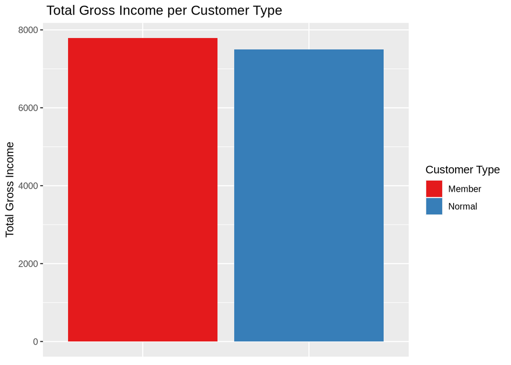

```r
# Which Customer Type Generates more Gross Income
by_cust <- sales_new %>%
  group_by(customer.type) %>%
  summarise(gross = sum(gross.income))

cust_type <- ggplot(by_cust, aes(x=customer.type, y= gross, fill=customer.type))+geom_bar(stat = "identity")+ labs(title = " Total Gross Income per Customer Type", x="Customer Type",y="Total Gross Income")
cust_type + scale_fill_brewer( name= "Customer Type",palette="Set1")+theme(axis.title.x=element_blank(),
        axis.text.x=element_blank(),
        axis.ticks.x=element_blank())
```

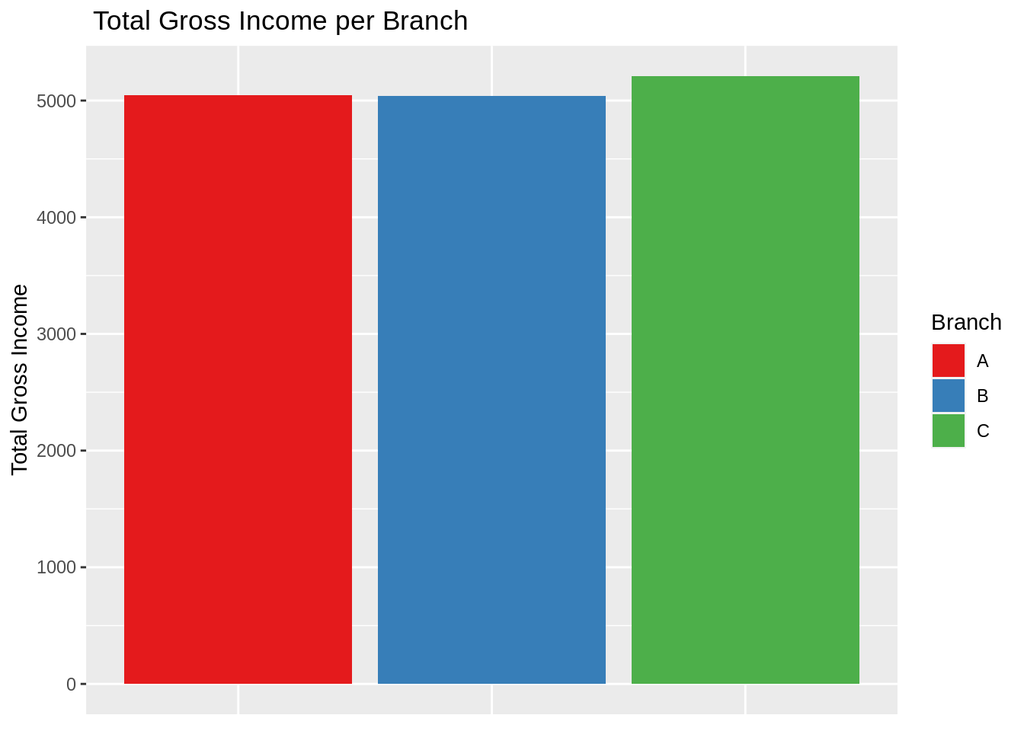

```r
# Branch with the Highest Gross Income
by_branch <- sales_new %>%
  group_by(branch) %>%
  summarise(gross = sum(gross.income))

branch_gross <- ggplot(by_branch, aes(x=branch, y= gross, fill=branch))+geom_bar(stat = "identity")+ labs(title = " Total Gross Income per Branch", x="Branch",y="Total Gross Income")
branch_gross + scale_fill_brewer(name="Branch",palette="Set1")+theme(
        axis.title.x=element_blank(),
        axis.text.x=element_blank(),
        axis.ticks.x=element_blank())
```

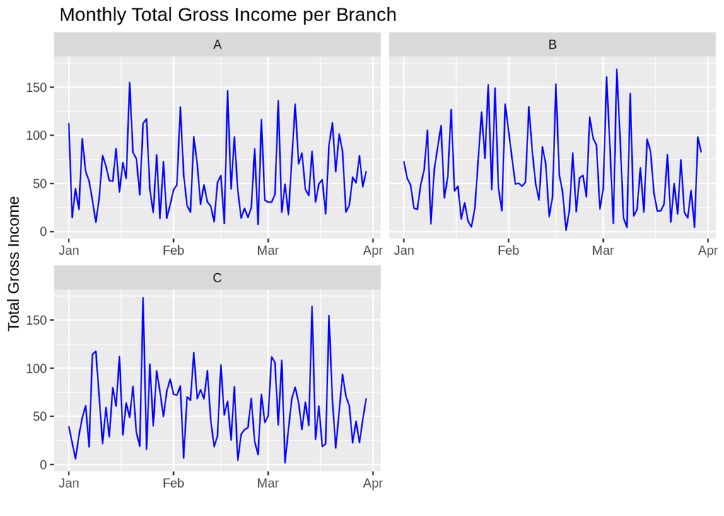

```r
# Monthly Gross Income

sales_new$date <- as.Date(sales_new$date, format = "%m/%d/%Y")

by_date <- sales_new %>%
  group_by(date, branch) %>%
  summarise(gross = sum(gross.income))


month_gross <- ggplot(by_date, aes(x=date, y=gross)) +geom_line(color="blue") + labs(title = " Monthly Total Gross Income per Branch", x="",y="Total Gross Income")+facet_wrap(~branch, scales = "free_x", ncol=2)
month_gross
```

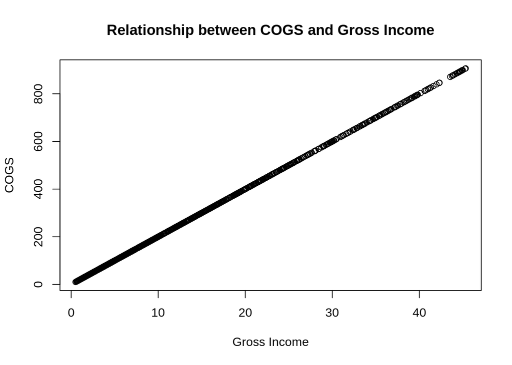

```r
plot(sales_new$gross.income, sales_new$cogs, main = "Relationship between COGS and Gross Income", xlab="Gross Income", ylab="COGS")
```

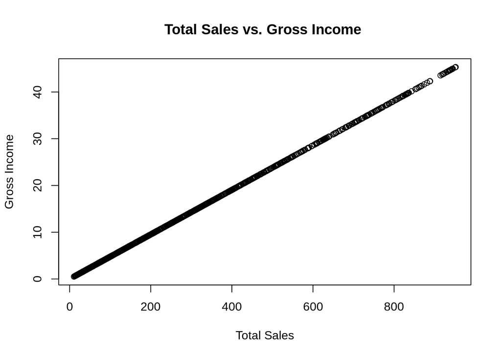

```r
plot(sales_new$total, sales_new$gross.income, main = "Total Sales vs. Gross Income ", xlab = "Total Sales", ylab = "Gross Income")
```

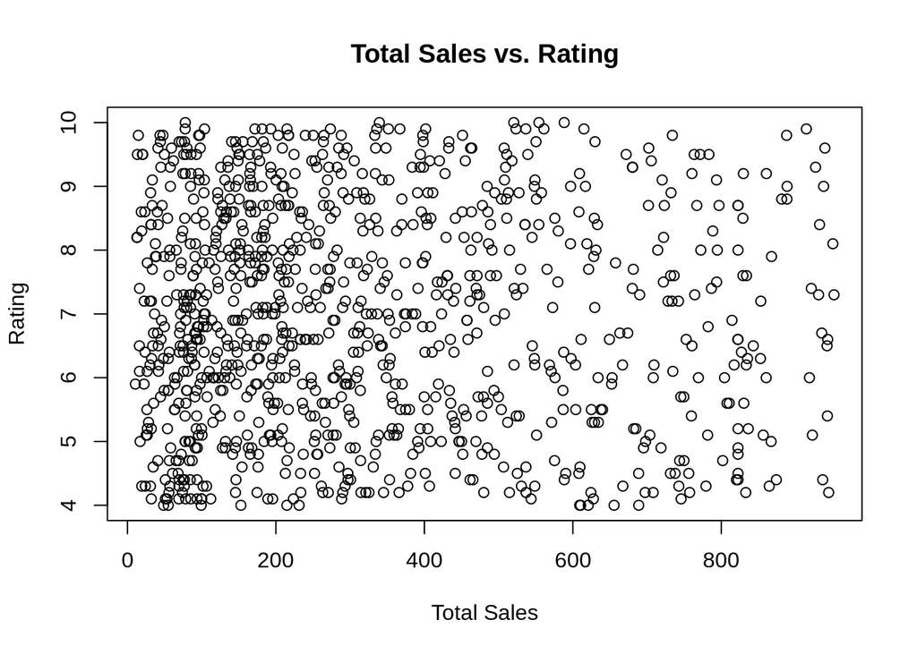

```r
plot(sales_new$total, sales_new$rating, main = "Total Sales vs. Rating", xlab = "Total Sales", ylab = "Rating")
```

In the Univariate Analysis we observed the following:-

Customer Type were only 2 types, and the both had equal distribution as well as the Gender The most popular Branch is Branch A, B then C but the difference between the two is very minimal. In Product Line, the *Fashion Accessories* were the most popular product line, followed by *Food & Beverages*, *Electronic Accessories* The most popular mode of Payment is through the E-Wallet

In the Branches there were also interesting observations, in Branch A the most popular Product Line are:-

1. Home & Lifestyle
2. Sports & Travel
3. Electronic Accessories

In Branch B we have:

1. Sports & Travel and Health & Beauty
2. Electronic Accessories

In Branch C we have:

1. Food & Beverages
2. Fashion & Accessories
3. Electronic Accessories

In terms of Most frequent Customer Types in the Branches we have

Branch A -> Has more Normal Customers than Members Branch B -> Has more Normal Customers than Members, but the difference is slight Branch C -> Has more Members than Normal Customers

In terms of the gender we see that

Branch A -> Has more Males than Female Customers Branch B -> Has more Males than Female Customers Branch C -> Has more Females than Male Customers

This observations gives us interesting insights, we have the most popular Product Line in Branch A and B is mostly Sports & Travel and Electronics Accessories while the most frequent customers in this Branches are Male Customers and the most frequent Customer Type in this Branches are Normal Customers.

We can say that in Branch A and B we have more Male Customers who are not members, Marketing team can look into targeting these customers in making them Members to establish a permanent relationship and also look into targeting Female Customers in this branches

In Branches C, we have more Female Customers with most bought products being Food & Beverages and Fashion Accessories, the most popular Customer Types are Members, therefore the Marketing Team can look into what influences the Female Customers in Branch C and apply it to Branch A and b The Team can do the same for Branch C, look into what influences customers in Branch A and B and apply it. Further Analysis can be done on the specific Braches to see what insights we can draw from their customer behaviors

In Branch A the most popular mode of Payment is Ewallet then cash. In Branch B, the most of Payment is EWallet, In Branch C we have Cash as the mode Payment. Members Mostly use Credit Card and Normal Customers use EWallet.

In Histogram there are no numeric columns are normally distributed.

The Categorical variables were encoded using Ordinal Encoding and created new columns.

In the Correlation we see that the features:-

1. Cogs
2. Total
3. Gross Income

were perfectly correlated with a correlation of 1

In the assumption that rating was done for Branch, we see that Branch C has the highest average Rating The Product Line with the Highest Gross Income:-

1. Food & Beverages
2. Sports & Travels
3. Electronic Accessories

The Marketing and Sales can look into the Product Lines so as to develop marketing strategies for those other Product Lines

At the end of March the Total Gross Income lowers except for Branch B where it starts to pick up

In Branch B between End of January and Beginning of March there is relatively High Total Gross Income

# Implement the Solution

## Dimension Reduction

```r
# PCA

# Features
predictors <- sales_new[, c(-1,-2,-3,-4,-8,-9,-10,-12,-15)]

sales.pca <- prcomp(predictors, scale. = TRUE, center = TRUE)
summary(sales.pca)
```

```
## Importance of components:
##                           PC1    PC2    PC3     PC4     PC5     PC6     PC7
## Standard deviation     1.9833 1.0666 1.0340 1.02345 0.99821 0.98287 0.95221
## Proportion of Variance 0.3576 0.1034 0.0972 0.09522 0.09058 0.08782 0.08243
## Cumulative Proportion  0.3576 0.4610 0.5582 0.65342 0.74400 0.83182 0.91425
##                            PC8     PC9      PC10      PC11
## Standard deviation     0.92755 0.28787 1.938e-16 8.482e-17
## Proportion of Variance 0.07821 0.00753 0.000e+00 0.000e+00
## Cumulative Proportion  0.99247 1.00000 1.000e+00 1.000e+00
```

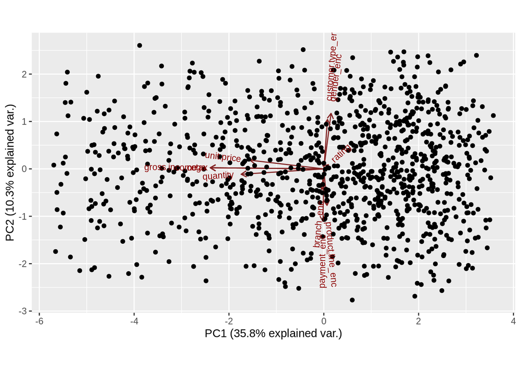

```r
label <- sales_new[, "total"]

library(ggbiplot)
ggbiplot(sales.pca, obs.scale = 1.2,var.scale=1.3)
```

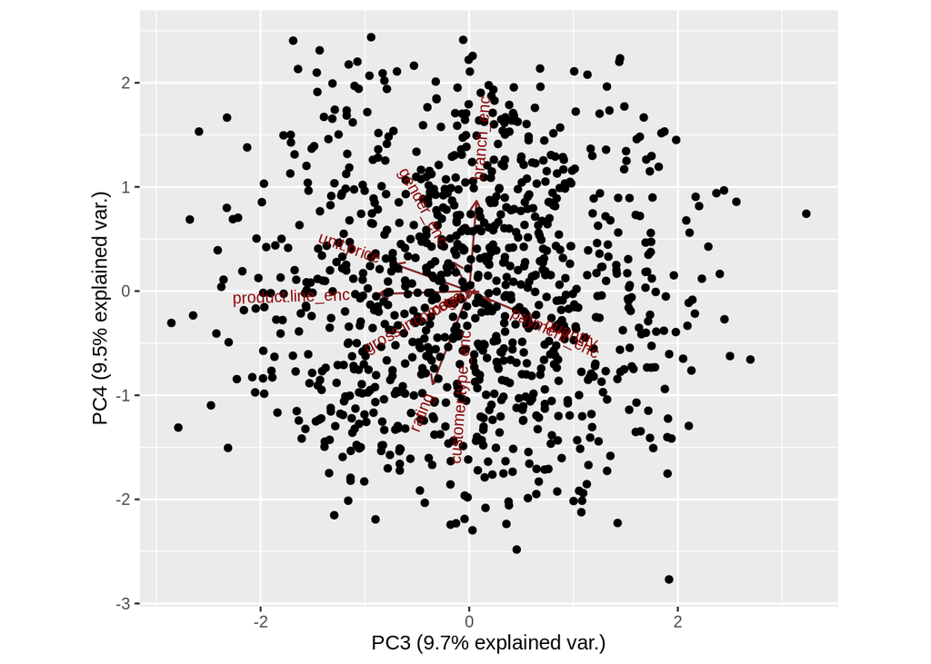

```r
ggbiplot(sales.pca, choices = c(3,4) ,obs.scale = 1.2, var.scale = 1.3)
```

## Feature Selection

```r
library(caret)
correlation = cor(predictors)

highly <- findCorrelation(correlation, cutoff = 0.75)
# highly correlated variables
names(predictors[,highly])
```

```
## [1] "tax"  "cogs"
```

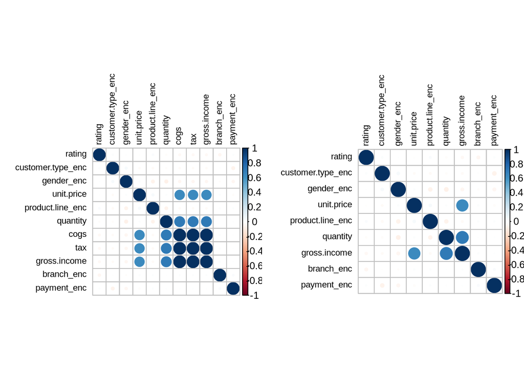

```r
# Dataset without the Highly Correlated
sales_new1 <- predictors[-highly]

#Plot
par(mfrow = c(1, 2))
corrplot(correlation, order = "hclust",tl.col = "black", tl.cex = 0.7)
corrplot(cor(sales_new1), order = "hclust",tl.col = "black", tl.cex = 0.7)
```

```r
library(clustvarsel)
library(mclust)

# perfectly correlated features

predictors_corr <- predictors[,c(-3,-4,-5)]

out = clustvarsel(predictors_corr, G=1:9)
out
```

```
## ------------------------------------------------------
## Variable selection for Gaussian model-based clustering
## Stepwise (forward/backward) greedy search
## ------------------------------------------------------
##
##  Variable proposed Type of step  BICclust Model G   BICdiff Decision
##           quantity          Add -4308.761     E 9  687.4466 Accepted
##        payment_enc          Add -6291.747   VEI 4  445.3485 Accepted
##         branch_enc          Add -9406.348   VEV 3 -660.5010 Rejected
##        payment_enc       Remove -4192.156     E 9  328.7436 Rejected
##
## Selected subset: quantity, payment_enc
```

```r
# Features selected
data <- predictors_corr[,out$subset]
head(data)
```

```
##   quantity payment_enc
## 1        7           1
## 2        5           2
## 3        7           3
## 4        8           1
## 5        7           1
## 6        7           1
```

```r
# Feature Ranking

# Removed Perfectly Correlated Variables
library(FSelector)

head(sales_new)
```

```
##   branch customer.type gender           product.line unit.price quantity
## 1      A        Member Female      Health and beauty      74.69        7
## 2      C        Normal Female Electronic accessories      15.28        5
## 3      A        Normal   Male     Home and lifestyle      46.33        7
## 4      A        Member   Male      Health and beauty      58.22        8
## 5      A        Normal   Male      Sports and travel      86.31        7
## 6      C        Normal   Male Electronic accessories      85.39        7
##       tax       date  time     payment   cogs gross.margin.percentage
## 1 26.1415 2019-01-05 13:08     Ewallet 522.83                4.761905
## 2  3.8200 2019-03-08 10:29        Cash  76.40                4.761905
## 3 16.2155 2019-03-03 13:23 Credit card 324.31                4.761905
## 4 23.2880 2019-01-27 20:33     Ewallet 465.76                4.761905
## 5 30.2085 2019-02-08 10:37     Ewallet 604.17                4.761905
## 6 29.8865 2019-03-25 18:30     Ewallet 597.73                4.761905
##   gross.income rating    total branch_enc customer.type_enc gender_enc
## 1      26.1415    9.1 548.9715          1                 1          1
## 2       3.8200    9.6  80.2200          2                 2          1
## 3      16.2155    7.4 340.5255          1                 2          2
## 4      23.2880    8.4 489.0480          1                 1          2
## 5      30.2085    5.3 634.3785          1                 2          2
## 6      29.8865    4.1 627.6165          2                 2          2
##   product.line_enc payment_enc
## 1                1           1
## 2                2           2
## 3                3           3
## 4                1           1
## 5                4           1
## 6                2           1
```

```r
predictors1 <- sales_new[, c(-1,-2,-3,-4,-7,-8,-9,-10,-11,-12,-13)]

Scores <- linear.correlation(total~., predictors1)
Scores
```

```
##                   attr_importance
## unit.price            0.633840195
## quantity              0.707051294
## rating                0.033923648
## branch_enc            0.012050301
## customer.type_enc     0.022321843
## gender_enc            0.047850581
## product.line_enc      0.022458599
## payment_enc           0.007536008
```

```r
# Selected Features
Subset <- cutoff.k(Scores, 5)
as.data.frame(Subset)
```

```
##             Subset
## 1         quantity
## 2       unit.price
## 3       gender_enc
## 4           rating
## 5 product.line_enc
```

1. Branch
2. Customer Type
3. Gender
4. Product Line
5. Payment
6. Unit Price
7. Quantity
8. Gross Income
9. Rating

Excluding the Total column for it the Label column

The Wrapper method selected, it excluded the perfectly correlated features and it returned

1. Quantity
2. Payment

When building an Unsupervised or Supervised model to predict on Total Sales the Features generated by each of the methods could be used and see which group of Features will generate the best accuracy